# Investing_3002

Frank Agyemang

2026-08-14

# Tracking returns of stocks that i lost money in for the past year

In my experience of investing, selecting the right stocks for either long term or short term is very difficult. Nevertheless, there are records of individuals who have built successful strategies to investing. Reading about some of these individuals and through my extensive knowledge in Economics and Financial Markets, i believe there are laid out rules that may maximize an investor’s return.I have broken down this into steps.

1. Scan stocks to determine those that have earning potential (this depends on an investor’s strategy). For the average investor and trader, we look for stocks that are performing well in the market. Other traders may look for stocks that may have the potential to do bad and trade on the Options (Put Options) market. Thus, a way to scan stocks is by looking at the returns of the stocks. NB:(If you are seeking to trade during the week, look at weekly data, monthly for monthly investment, yearly data for long term data etc…) and select prefered stocks.
2. Read about the stocks and their underlying (what tangible goods actually support the stock) and how are those goods performing on the market (This serves as a confirmation step of previously selected stocks)
3. Portfolio Optimization (codes provided for statistical analysis)
4. Observe the stock performance for the day to validate the strategy before investing the next day.
5. These steps help with entry of the market and exit strategies

[output not shown]

## Stock Return Analysis: Fetch, Compute Returns, Plot, Decompose (EV / Auto / Mobility) & (AI)

```r
## Define tickers and date range

tickers <- c( "MULN", "NIO", "GOEV", "SVMH", "RYDE",
             "SES", "ATOM", "HOLO", "SOUN",
             "XTIA", "ONDS")
start_date <- "2025-07-01"
end_date   <- Sys.Date()
```

```
## Failed to download: MULN -- Unable to import "MULN".
## HTTP error 404.
```

```
## Failed to download: GOEV -- Unable to import "GOEV".
## HTTP error 404.
```

```
## Failed to download: SVMH -- Unable to import "SVMH".
## HTTP error 404.
```

```
## Skipped (failed to download): MULN, GOEV, SVMH
```

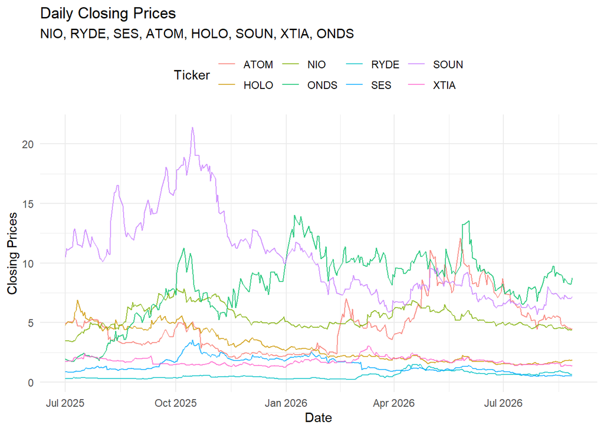

```r
## Plotting times series for stock prices
prices_df <- prices %>%
  fortify.zoo() %>%          # converts xts to data frame with a Date column
  rename(Date = Index) %>%
  pivot_longer(-Date, names_to = "Ticker", values_to = "Price")

ggplot(prices_df, aes(x = Date, y = Price, color = Ticker)) +
  geom_line(alpha = 0.8, linewidth = 0.4) +
  labs(title = "Daily Closing Prices",
       subtitle = paste(tickers, collapse = ", "),
       x = "Date", y = "Closing Prices") +
  theme_minimal() +
  theme(legend.position = "top")
```

```r
## Calculate daily returns
# Log returns (Used here)
returns_log <- na.omit(Return.calculate(prices, method = "log"))

## Superimposed time series plot of returns
returns_df <- returns_log %>%
  fortify.zoo() %>%          # converts xts to data frame with a Date column
  rename(Date = Index) %>%
  pivot_longer(-Date, names_to = "Ticker", values_to = "Return")

daily_ret <- ggplot(returns_df, aes(x = Date, y = Return, color = Ticker)) +
  geom_line(alpha = 0.8, linewidth = 0.4) +
  labs(title = "Daily Log Returns",
       subtitle = paste(tickers, collapse = ", "),
       x = "Date", y = "Log Return") +
  theme_minimal() +
  theme(legend.position = "top")

# Save Plot
ggsave(filename = "Daily Returns Auto AI.png",
       plot = daily_ret,
       width = 8,
       height = 6,units = "in", dpi = 300)
```

```r
##  Decomposition: trend, seasonality, cyclicality, residual
##   This requires the `mFilter` package

decompose_stock <- function(ret_xts, ticker, frequency = 21) {
  # frequency = 21 treats a trading month as the "seasonal" period;
  # use 5 for a trading week, or 252 for an annual cycle instead.
  ts_data <- ts(as.numeric(ret_xts), frequency = frequency)

  stl_fit <- stl(ts_data, s.window = "periodic", robust = TRUE)
  comp <- as.data.frame(stl_fit$time.series)  # seasonal, trend, remainder
  # Further split the STL trend into long-run trend + cycle via HP filter
  hp_fit <- hpfilter(comp$trend, freq = 14400)  # 14400 is a common daily-data lambda
  comp$long_run_trend <- as.numeric(hp_fit$trend)
  comp$cycle          <- as.numeric(hp_fit$cycle)

  comp$Date   <- index(ret_xts)
  comp$Ticker <- ticker
  comp
}
```

```r
decomp_list <- lapply(tickers, function(t) decompose_stock(returns_log [, t], t))
decomp_all  <- bind_rows(decomp_list)
```

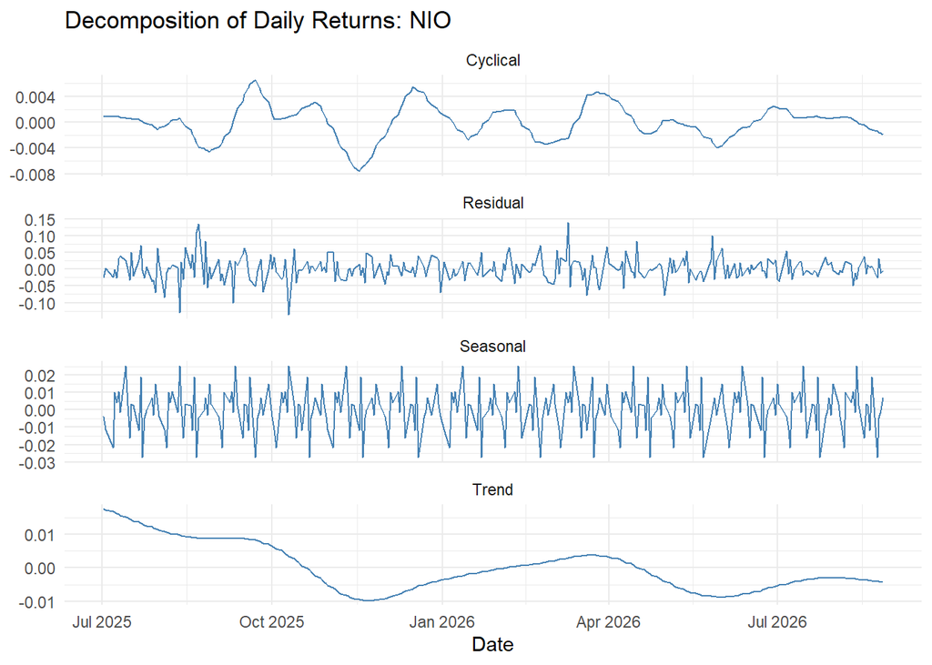

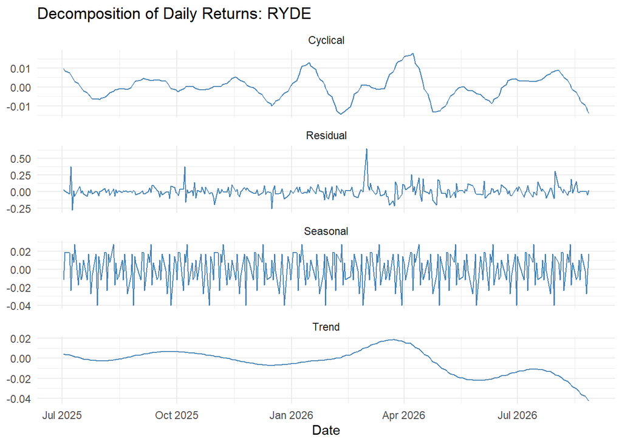

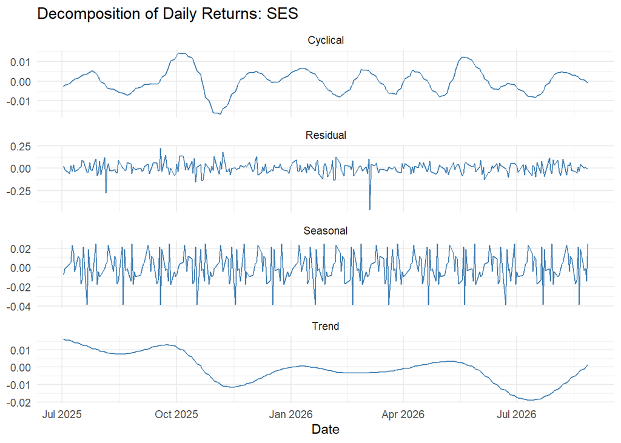

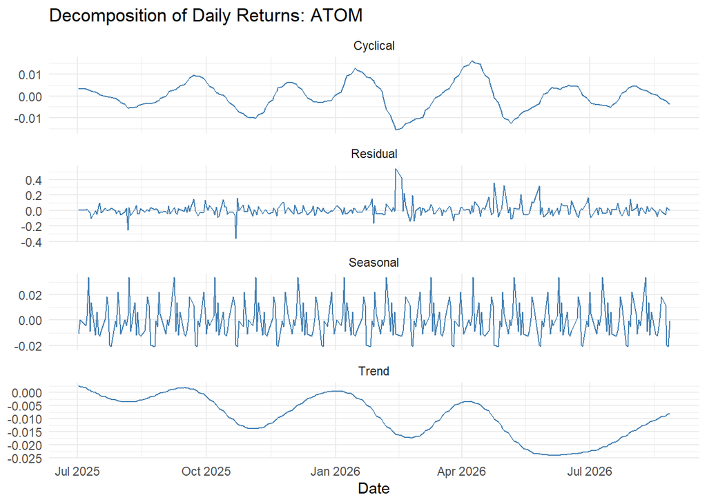

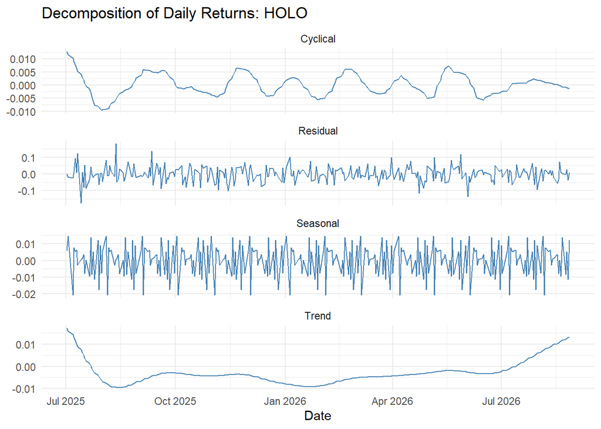

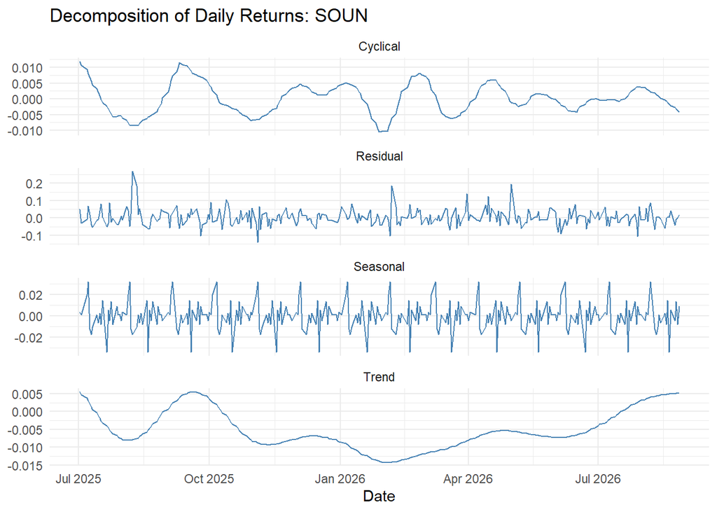

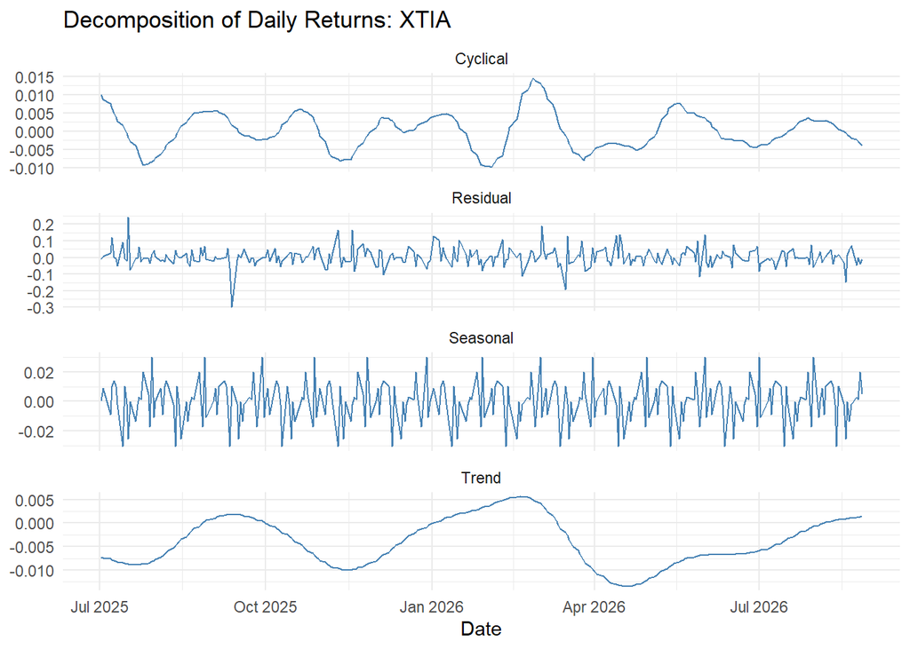

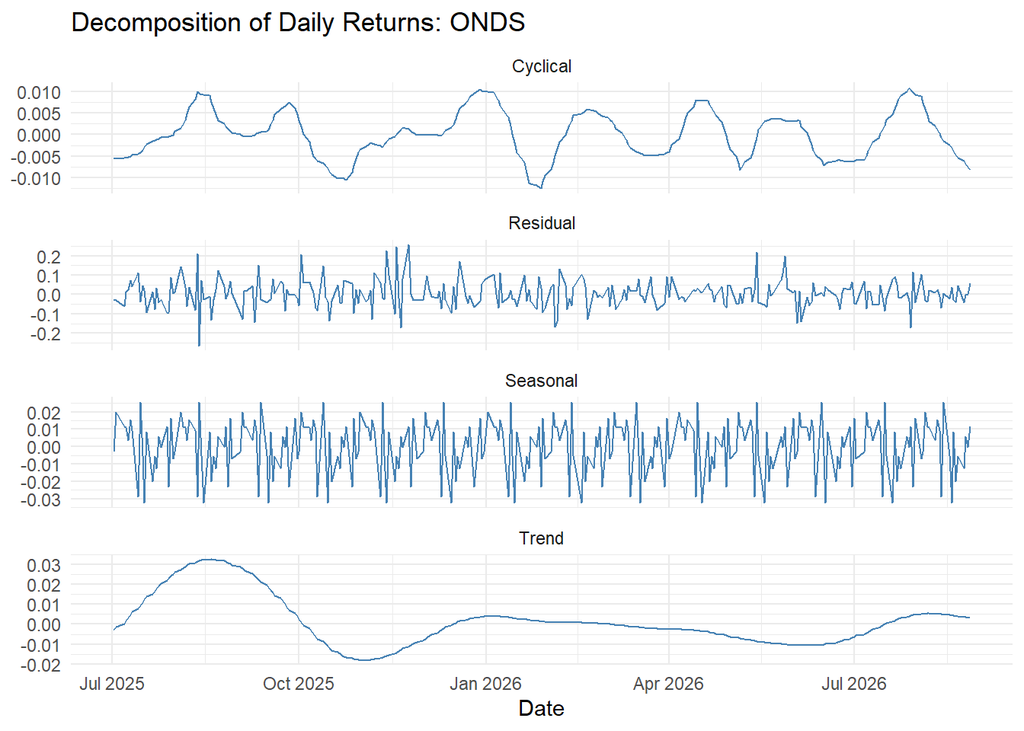

```r
##  Plot each stock's decomposition
plot_decomposition <- function(df, ticker) {
  df_long <- df %>%
    filter(Ticker == ticker) %>%
    select(Date, seasonal, long_run_trend, cycle, remainder) %>%
    rename(Trend = long_run_trend, Seasonal = seasonal,
           Cyclical = cycle, Residual = remainder) %>%
    pivot_longer(-Date, names_to = "Component", values_to = "Value")

  ggplot(df_long, aes(x = Date, y = Value)) +
    geom_line(color = "steelblue", linewidth = 0.4) +
    facet_wrap(~ Component, scales = "free_y", ncol = 1) +
    labs(title = paste("Decomposition of Daily Returns:", ticker),
         x = "Date", y = NULL) +
    theme_minimal()
}

# Example: plot decomposition for each ticker
for (t in tickers) {
  print(plot_decomposition(decomp_all, t))
}
```

```r
##  (Optional) Save plots to files
ggsave("returns_superimposed.png", width = 10, height = 6)
 for (t in tickers) {
  ggsave(paste0("decomp_", t, ".png"), plot = plot_decomposition(decomp_all, t),
          width = 8, height = 8)
}
```

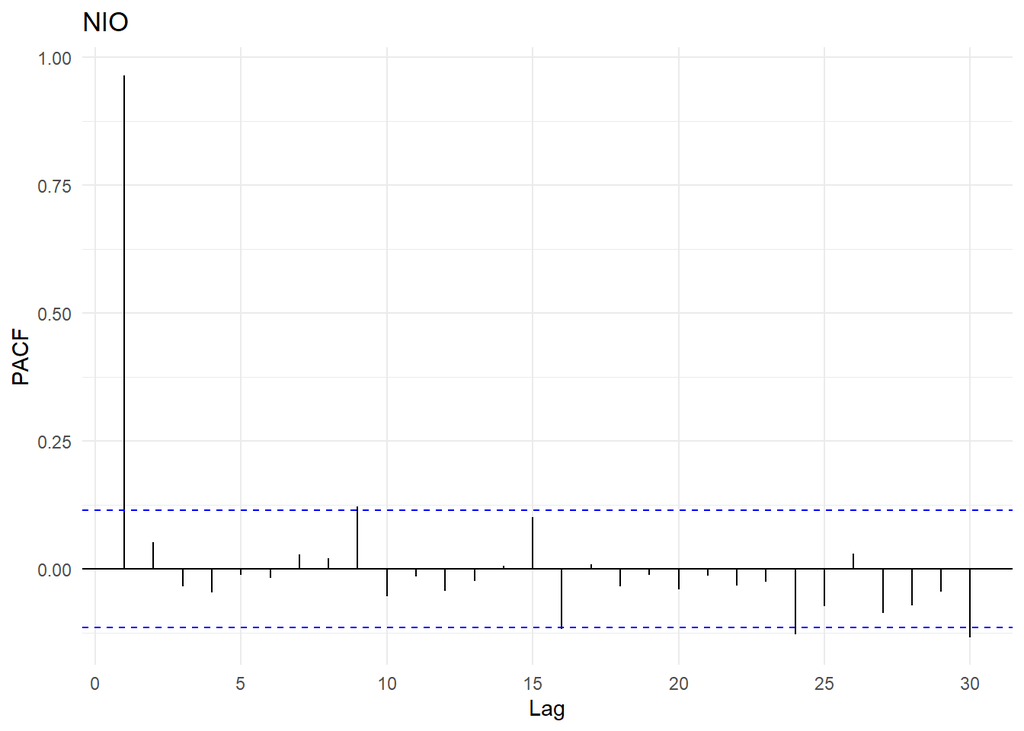

```r
## Get ACF for all stocks in BioPharma
## Individual ACF plots using ggplot2 (nicer styling)
acf_plot_list <- lapply(colnames(prices), function(t) {
  ggPacf(as.numeric(prices[, t]), lag.max = 30) +
    ggtitle(t) +
    theme_minimal()
})

acf_plot_list[[1]]
```

```r
# Test for stationarity

## ---- Loop across all stocks in `returns` (or `prices`) ----
for (t in colnames(returns_log)) {
  result <- adf.test(as.numeric(na.omit(returns_log[, t])))
  cat(sprintf("%-6s  ADF stat: %.4f   p-value: %.4f   %s\n",
              t, result$statistic, result$p.value,
              ifelse(result$p.value < 0.05, "-> Stationary", "-> Non-stationary")))
}
```

```
## NIO     ADF stat: -6.6268   p-value: 0.0100   -> Stationary
## RYDE    ADF stat: -5.5696   p-value: 0.0100   -> Stationary
## SES     ADF stat: -6.2438   p-value: 0.0100   -> Stationary
## ATOM    ADF stat: -6.6140   p-value: 0.0100   -> Stationary
## HOLO    ADF stat: -8.8086   p-value: 0.0100   -> Stationary
## SOUN    ADF stat: -7.3124   p-value: 0.0100   -> Stationary
## XTIA    ADF stat: -6.5244   p-value: 0.0100   -> Stationary
## ONDS    ADF stat: -6.7615   p-value: 0.0100   -> Stationary
```